# Results

## Enrichment analyses

### Single

We first examined the univariate enrichment of SCZ risk variants in ASoC SNPs, OCRs and other annotated genomic regions, by using TORUS. Red dots and black bars represent enrichment odds ratio and 95% confidence interval, respectively. If the confidence interval does not include 0, we call the enrichment result statistically significant.

iN-Glut ASoC variants showed over 100-fold remarkable enrichment for SCZ risk variants, while NPC ASoC variants showed ~66-fold enrichment. In contrast, both iN-Glut and NPC OCRs revealed only ~3-fold enrichments (Fig 1). In other words, the function of neuronal ASoC iN-Glut and NPC variants are more highlighted than that in their corresponding OCRs. Other OCRs (iN-GA, iN-DN, iPSC) indicated significant enrichment as well. Nevertheless, the bar widths for ASoC variants are greater than those of OCRs, for the reason that the number of SCZ variants that overlap with ASoC SNPs is much fewer than those captured by OCR peaks.

It has been widely proven that SCZ risk loci are enriched in non-coding regulatory regions (1). We verified that conserved and 3'UTR sequences were slightly more enriched for SCZ risk variants than coding regions. Furthermore, SCZ risk variants were also highly enriched in 5'UTR and promoter sequences. We further performed single-annotation analysis using brain eQTL for comparison, since it has been demonstrated that aggregate associations between brain eQTLs and many brain disorder GWAS variants, such as SCZ (2). We discovered that brain eQTL revealed ~4-fold enrichment for SCZ risk variants (Fig 1). Specifically, it should be noted that repressed regions, also called inactive regions (3), showed negative enrichment (odds ratio less than 1) of SCZ risk variants, because it is strongly indicated that the genes within repressed regions are silenced (3).

1. https://www.ncbi.nlm.nih.gov/pmc/articles/PMC4255904/
2. https://science.sciencemag.org/content/362/6420/eaat8464
3. https://www.ncbi.nlm.nih.gov/pmc/articles/PMC3553955/pdf/gks1284.pdf

Figure 1: Enrichment analysis results of SCZ risk variants for single genomic region (univariate analysis): ASoC variants, OCRs and other functional annotations including coding, promoter, conserved sequences, repressed regions, brain eQTL, etc. Red dots indicate the log2 odds ratio of enrichment of GWAS SNPs captured by genomic regions or SNPs versus those are not, and bar ranges represent the corresponding 95% confidence interval.

> /home/min/Documents/GWAS_ATAC/SCZ_plot/pgc2_enrichment_all_single_log2_20200618.pdf (5.7 KiB):

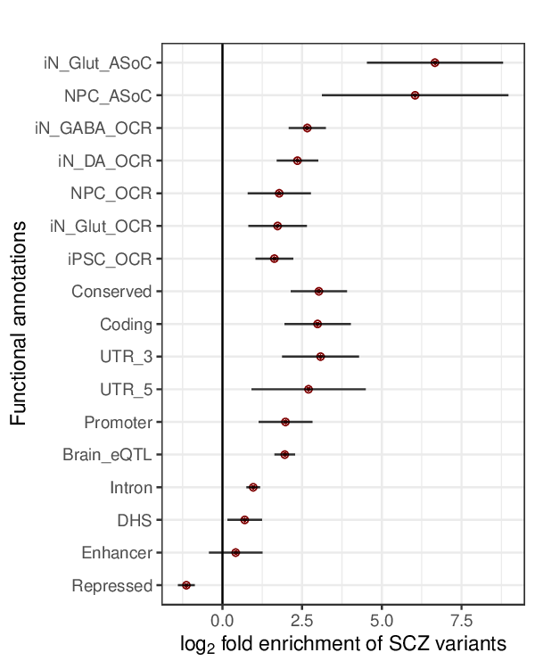

```python
%preview /home/min/Documents/GWAS_ATAC/SCZ_plot/pgc2_enrichment_all_single_log2_20200618.pdf -s png
```

To improve visuality and comparability, we made bubble heatmap plots (Fig. 3 and 4) with size and color attributes for 13 GWAS traits and 15 genomic annotations in Figures 1 and 2. The color of the bubbles indicated the magnitude of enrichment (log2 odds ratio), while the size of the bubbles indicated the significance level. By default, the bubble with darker color and larger size denotes the enrichment result of larger magnitude and higher significance level.

Figure 2: Enrichment of ASoC SNPs, OCRs, and annotated genomic regions for GWAS risk variants of different diseases and traits.

(A-L): Enrichment analysis results from TORUS. Diseases/traits that did not show enrichment in OCR or ASoC in Figure 1 are not shown.

> /home/min/Documents/GWAS_ATAC/SCZ_plot/Enrichment_single.png (234.6 KiB):

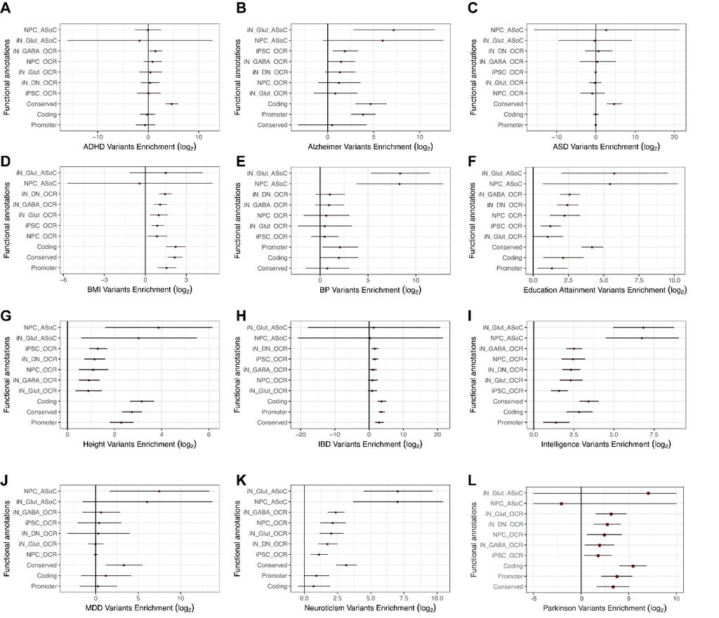

```python
%preview /home/min/Documents/GWAS_ATAC/SCZ_plot/Enrichment_single.png -s png
```

Figure 3. Enrichment of risk variants of 13 disorders/traits in ASoC SNPs and OCRs.

> /home/min/Documents/GWAS_ATAC/SCZ_plot/atac_seq_log2_20200622.pdf (8.2 KiB):

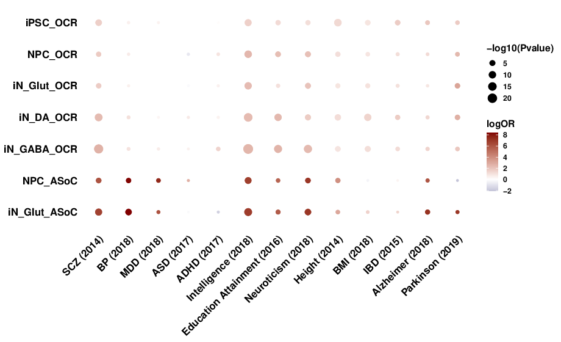

```python
%preview /home/min/Documents/GWAS_ATAC/SCZ_plot/atac_seq_log2_20200622.pdf -s png --dpi 80
```

Figure 4. Enrichment of risk variants of 13 disorders/traits in other functional genomic regions.

> /home/min/Documents/GWAS_ATAC/SCZ_plot/general_log2_20200622.pdf (8.4 KiB):

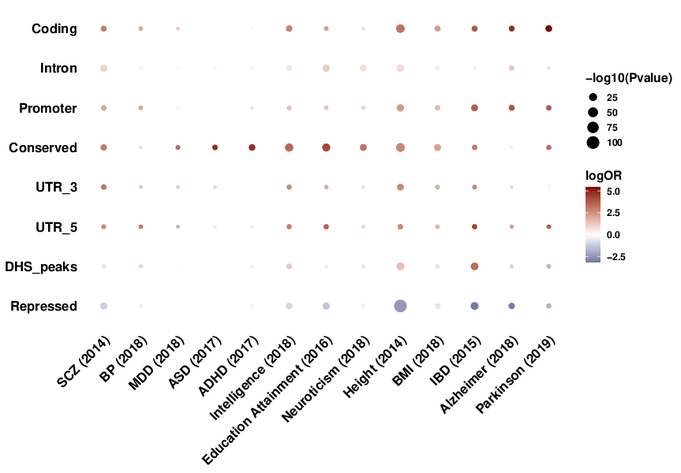

```python
%preview /home/min/Documents/GWAS_ATAC/SCZ_plot/general_log2_20200622.pdf -s png --dpi 80
```

For control disorders and traits, it showed little or no enrichment in ASoC SNPs and OCRs as expected (Fig. 5). For instance, the dots for LDL and T2D are light and small, indicating inconsiderable enrichment magnitude, or even slightly negative enrichment, as well as weak statistical significance. These results suggest that risk variants in neuropsychiatric disorders are likely to be linked to neuronal ASoC SNPs and OCRs, and highlight the advantage to utilize ASoC SNPs and OCRs in prioritizing non-coding region risk variant studies.

Figure 5. Enrichment of risk variants of 9 control disorders/traits in ASoC SNPs and OCRs. Enrichment results of SCZ was placed at the first for comparison.

> /home/min/Documents/GWAS_ATAC/SCZ_plot/control_atac_seq_log2.20200622.pdf (7.6 KiB):

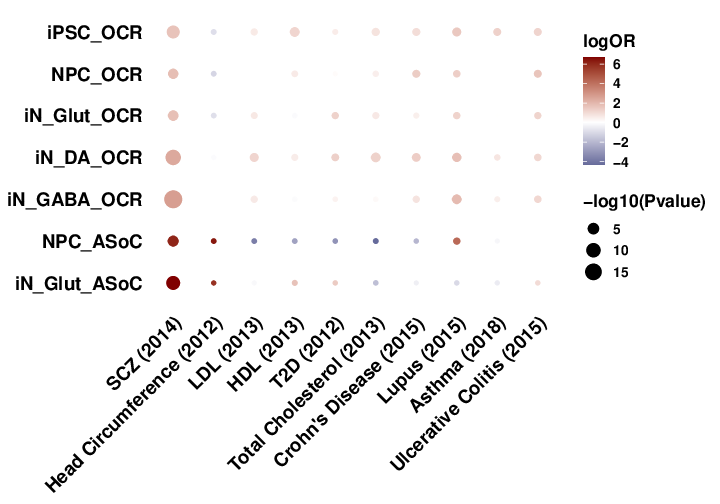

```python
%preview /home/min/Documents/GWAS_ATAC/SCZ_plot/control_atac_seq_log2.20200622.pdf -s png --dpi 90
```

In order to highlight ASoC SNPs as a functional mechanism of non-coding risk variants in neuropsychiatric disorders, we classified GWAS disorders/traits into 4 groups — neuropsychiatric, anthropometric, metabolic and immune disease (tab. 1), then used different colors to quantify enrichment magnitude and significance for 4 trait groups. The red dots, representing neuropsychiatric disorders, concentrated at right side of both figures, especially top right corner (large odds ratio and high significance level). Meanwhile, most anthropometric, metabolic and immune diseases/traits located at the bottom part, which are statistically insignificant in spite of some occasional large odds ratios.

```
Table 1: Classification of GWAS disorders/traits
Neuropsychiatric: SCZ, BIP, MDD, ASD, ADHD, intelligence, education attainment, neuroticism, Alzheimer's disease, Parkinson's disease
Anthropometric: head circumference, BMI, height
Metabolic: LDL, HDL, T2D, total cholesterol
Immune: Crohn's disease, IBD, lupus, asthma, ulcerative colitis
```

Figure 6. Enrichment magnitude and significance comparison for 4 disease/trait groups in ASoC SNPs.

> /home/min/Documents/GWAS_ATAC/SCZ_plot/Enrichment_significance_glut_20200622.pdf (19.6 KiB):

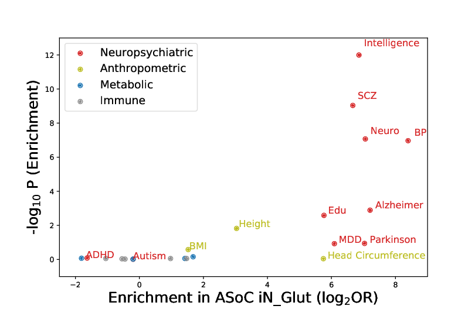

```python
%preview /home/min/Documents/GWAS_ATAC/SCZ_plot/Enrichment_significance_glut_20200622.pdf -s png --dpi 90
```

> /home/min/Documents/GWAS_ATAC/SCZ_plot/Enrichment_significance_npc_20200622.pdf (19.0 KiB):

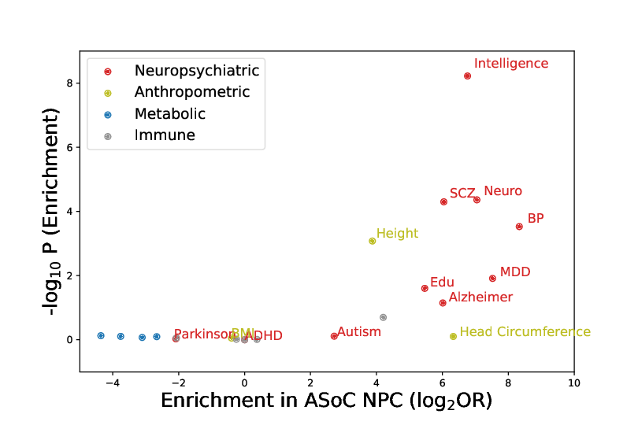

```python
%preview /home/min/Documents/GWAS_ATAC/SCZ_plot/Enrichment_significance_npc_20200622.pdf -s png --dpi 90
```

### Multiple

Figure 7. Enrichment of SCZ risk variants in multiple functional annotations.

```
A. 2 ASoC SNPs and 5 OCRs.
B. 2 ASoC SNPs, 5 OCRs as well as conserved, coding and promoter regions.
```

> /home/min/Documents/GWAS_ATAC/SCZ_plot/pgc2_enrichment_multi7.pdf (5.3 KiB):

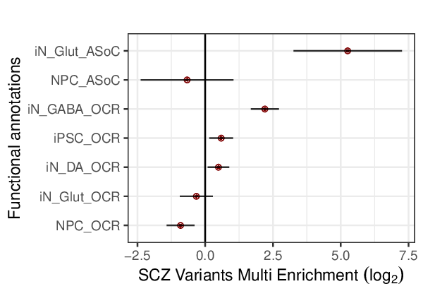

```python
%preview /home/min/Documents/GWAS_ATAC/SCZ_plot/pgc2_enrichment_multi7.pdf -s png
```

> /home/min/Documents/GWAS_ATAC/SCZ_plot/pgc2_enrichment_multi10.pdf (5.5 KiB):

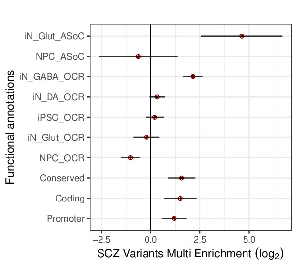

```python
%preview /home/min/Documents/GWAS_ATAC/SCZ_plot/pgc2_enrichment_multi10.pdf -s png
```

## Fine-mapping

Fine-mapping results incorporating differences informative or uninformative priors are illustrated by 2 SCZ genomic loci, harboring ~80 and ~500 GWAS SNPs, respectively. The smaller locus locates on chromosome 8, spanning 21 kilobase pairs. Fine-mapping using uniform priors produced one credible set containing 32 SNPs, of which the largest PIP was ~0.30. Fine-mapping using commonly known genomic features gave similar results with uniform priors. While fine-mapping with ASoC SNPs and OCRs priors yielded one credible set of 23 SNPs, and the largest PIP was over 0.50, and the corresponding SNP was not the one with largest PIP using uniform priors (Fig. 8).

Figure 8. Fine-mapping results of locus chr8: 143309503-143330533. Uniform/general vs atac-seq/atac-seq_asca

> /home/min/Documents/GWAS_ATAC/reference/chr8_143309503_143330533.uniform.L_1.prior_5e_05.pdf (6.2 KiB):

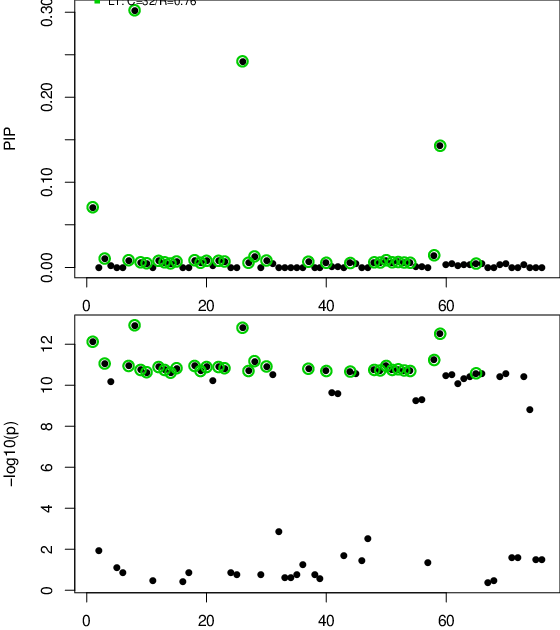

```python
%preview /home/min/Documents/GWAS_ATAC/reference/chr8_143309503_143330533.uniform.L_1.prior_5e_05.pdf -s png --dpi 70
```

> /home/min/Documents/GWAS_ATAC/reference/chr8_143309503_143330533.general.L_1.prior_5e_05.pdf (6.2 KiB):

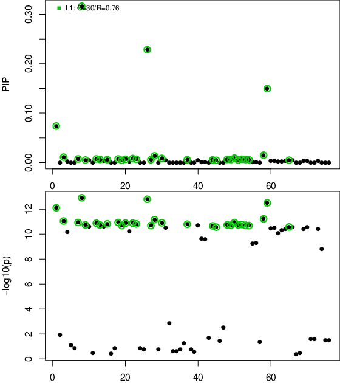

```python
%preview /home/min/Documents/GWAS_ATAC/reference/chr8_143309503_143330533.general.L_1.prior_5e_05.pdf -s png --dpi 70
```

> /home/min/Documents/GWAS_ATAC/reference/chr8_143309503_143330533.atac-seq_asca.L_1.prior_5e_05.pdf (6.1 KiB):

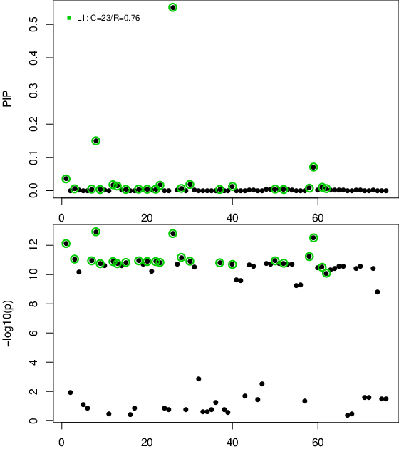

```python
%preview /home/min/Documents/GWAS_ATAC/reference/chr8_143309503_143330533.atac-seq_asca.L_1.prior_5e_05.pdf -s png --dpi 70
```

The second locus locates on chromosome 5 and spans over 199 KB. Similarly to the first locus, fine-mapping results using ASoC SNPs and OCRs priors are more clear and reasonable, and yield the largest PIP, which is much larger than top PIPs in other two scenarios. Moreover, PIPs for all other SNPs are reduced to almost zero (Fig. 9).

Many of the 108 loci showed similar circumstance with the two examples, which claimed the importance and informativeness of ASoC SNPs and OCRs, especially ASoC SNPs, in the process of detecting functional variants. We will summarize all loci in next section (Fig. 12).

Figure 9. Fine-mapping results of locus chr5: 140023664-140222664. uniform, general, atac-seq_asca

> /home/min/Documents/GWAS_ATAC/reference/chr5_140023664_140222664.uniform.L_1.prior_5e_05.pdf (13.4 KiB):

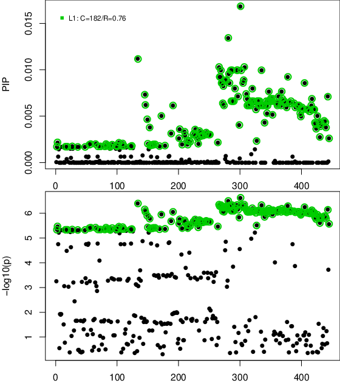

```python
%preview /home/min/Documents/GWAS_ATAC/reference/chr5_140023664_140222664.uniform.L_1.prior_5e_05.pdf -s png --dpi 70
```

> /home/min/Documents/GWAS_ATAC/reference/chr5_140023664_140222664.general.L_1.prior_5e_05.pdf (13.0 KiB):

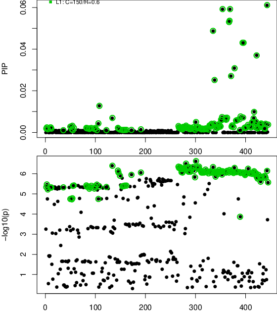

```python
%preview /home/min/Documents/GWAS_ATAC/reference/chr5_140023664_140222664.general.L_1.prior_5e_05.pdf -s png --dpi 70
```

> /home/min/Documents/GWAS_ATAC/reference/chr5_140023664_140222664.atac-seq_asca.L_1.prior_5e_05.pdf (12.8 KiB):

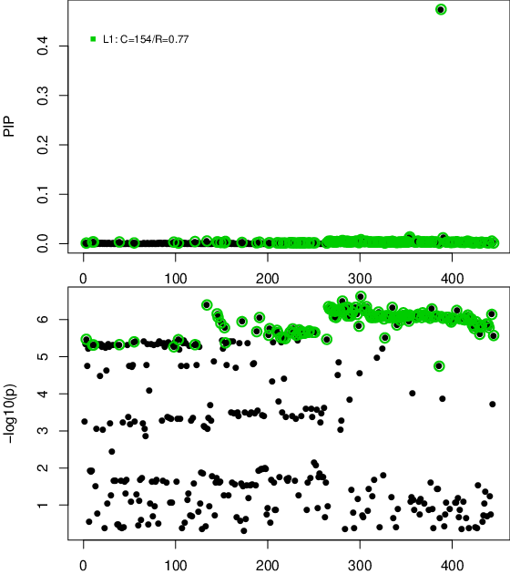

```python
%preview /home/min/Documents/GWAS_ATAC/reference/chr5_140023664_140222664.atac-seq_asca.L_1.prior_5e_05.pdf -s png --dpi 70
```

> /home/min/Documents/GWAS_ATAC/reference/susie_scatterplot.pdf (24.3 KiB):

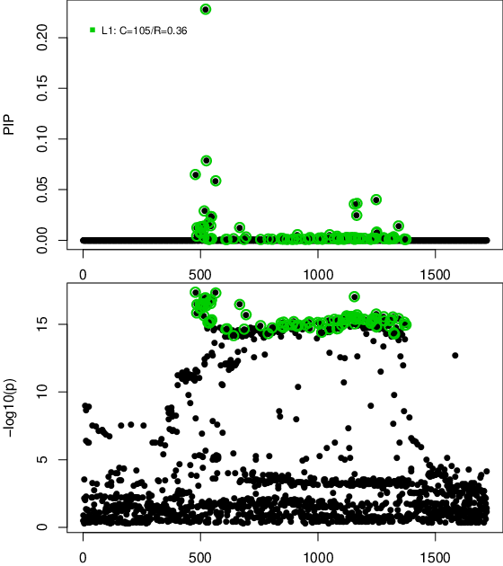

```python
%preview /home/min/Documents/GWAS_ATAC/reference/susie_scatterplot.pdf -s png --dpi 70
```

When we set the maximum number of causal variants in a locus, L, to more than 1, the results revealed 2 or more credible sets (Fig. 11B). The black dots with green and blue circles represented 2 credible sets, each aiming at capturing one functional SNP.

Figure 11. Fine-mapping results with different L yield different credible sets.

> /home/min/Documents/GWAS_ATAC/reference/chr1_97792625_98559084.atac-seq_asca.L_1.prior_5e_05.pdf (25.2 KiB):

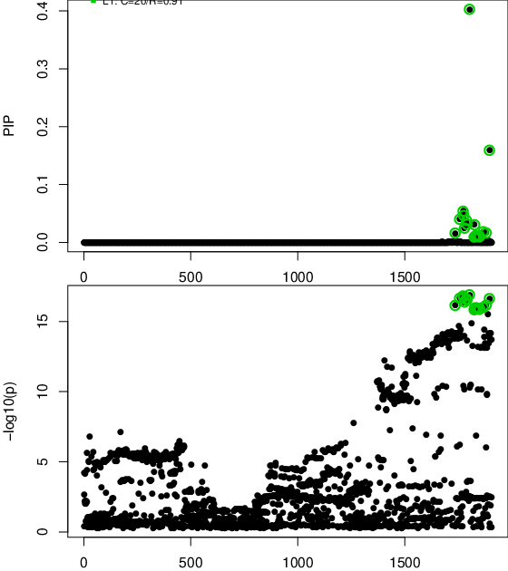

```python
%preview /home/min/Documents/GWAS_ATAC/reference/chr1_97792625_98559084.atac-seq_asca.L_1.prior_5e_05.pdf -s png --dpi 70
```

> /home/min/Documents/GWAS_ATAC/reference/chr1_97792625_98559084.atac-seq_asca.L_3.prior_0p005.pdf (28.3 KiB):

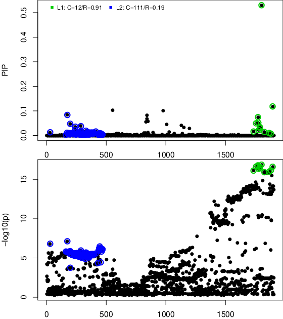

```python
%preview /home/min/Documents/GWAS_ATAC/reference/chr1_97792625_98559084.atac-seq_asca.L_3.prior_0p005.pdf -s png --dpi 70
```

### Scatter plot

We merged fine-mapping results of SNPs from all 108 GWAS loci and then compared the effects of different functional genomic features more directly in one figure (Fig. 12). The x-axis represents PIPs from uniform priors, while y-axis represents PIPs from joint ASoC and OCRs priors. Red dots represent GWAS SNPs overlapped with either of 2 types of ASoC SNPs; yellow dots represent GWAS SNPs captured by OCRs; blue dots represent GWAS SNPs not located within OCRs. It is easily seen that most blue dots locate on or below the diagonal, indicating that SNPs not associated with ASoC or OCRs tend to have equal or lower PIPs when integrating functional feature priors for fine-mapping. In contrast, most red and yellow dots locate above the diagonal, specifically the red dots showed strong difference between two priors, highlighting ASoC as a functional mechanism of non-coding neuropsychiatric risk variants. This integrated method of fine-mapping with functional genomics data provides a powerful framework for identifying disease functional variants/genes.

Figure 12. Directly comparison of SuSiE PIPs from different priors for 108 SCZ GWAS significant loci.

> /home/min/Documents/SuSiE_GWAS/SCZ/aa_un.pdf (66.9 KiB):

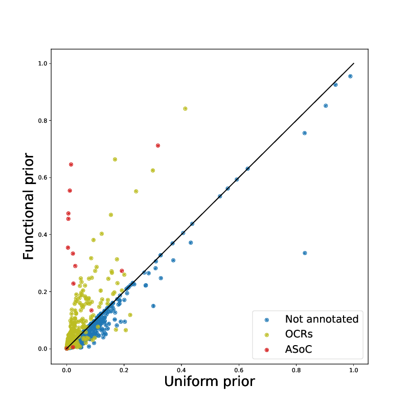

```python
%preview /home/min/Documents/SuSiE_GWAS/SCZ/aa_un.pdf -s png --dpi 80
```

Our fine-mapping analysis using SuSiE reported PIPs of SCZ variants. To estimate the percentage contribution of ASoC SNPs to disease risk, we summed over the PIPs of all ASoC iN-Glut and NPC SNPs, and divided that by the total PIPs of all SCZ GWAS SNPs. Consequently, we detected that non-coding SNPs in OCRs accounted for 9.4% of SCZ genome-wide SNPs and explained 22.5% of SCZ risk. In contrast, 2 types of ASoC SNPs, which accounted for only 0.08% of the SCZ SNPs, yet explained 5.5% of SCZ risk, a 67-fold enrichment. Considering that ASoC SNPs are only a small proportion of SNPs located in OCRs, ASoC SNPs are more enriched for SCZ GWAS risk variants, which justifies our proposition of utilizing ASoC to prioritize those risk variants that are more likely to be functional and potentially causal. This enrichment and fine-mapping approach is equally applicable to other neurodevelopmental brain disorders.

Figure 13. Percentage of SNPs and risk variants explained by ASoC and OCR in SCZ.

> /home/min/Documents/GWAS_ATAC/SCZ_plot/Barplot_scz_20200318.pdf (13.7 KiB):

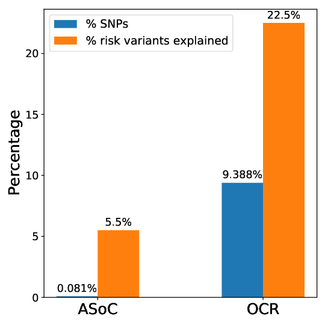

```python
%preview /home/min/Documents/GWAS_ATAC/SCZ_plot/Barplot_scz_20200318.pdf -s png --dpi 90
```

## 20 loci

We also made a scatter plot for SNPs from the corresponding loci of the 20 targeted SNPs (Fig. 14). To make a distinction with Figure 12, we used another group of annotation priors — X axis is SuSiE PIPs using 8 commonly known genomic regions in Figure 4, also called general annotations, while y axis is SuSiE PIPs using all 15 annotations in Figures 3 and 4. Similar to Figure 12, SNPs annotated with ASoC (red dots in Fig 14) showed significantly large PIPs by integration of neuronal annotations, and SNPs only captured by genomic regions (not captured with neuronal annotations, blue and grey dots in Fig 14) showed smaller PIPs after adding neuronal annotations.

Figure 14. Directly comparison of SuSiE PIPs from different priors for 20 selected SNPs' corresponding loci.

> /home/min/Documents/SuSiE_GWAS/SCZ/al_ge_21loci_20200624.pdf (24.0 KiB):

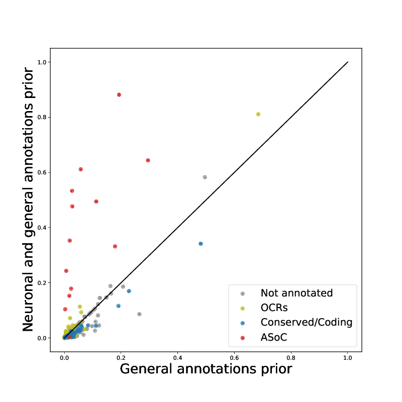

```python
%preview /home/min/Documents/SuSiE_GWAS/SCZ/al_ge_21loci_20200624.pdf -s png --dpi 80
```

## VPS45

1. I. Dulubova et al., How Tlg2p/syntaxin 16 'snares' Vps45. EMBO J 21, 3620-3631 (2002).
2. K. K. Marballi, A. L. Gallitano, Immediate Early Genes Anchor a Biological Pathway of Proteins Required for Memory Formation, Long-Term Depression and Risk for Schizophrenia. Front Behav Neurosci 12, 23 (2018).

Figure 15. Fine-mapping the VPS45 locus where SNP rs2027349 locates. Left y-axis: –log10 p-values from SCZ GWAS (blue points above the x-axis); right y-axis: PIPs (red points below the x-axis); vertical grey bar: rs2027349.

> /home/min/Documents/GWAS_ATAC/SCZ_plot/GB_VPS45_20200624.pdf (562.7 KiB):

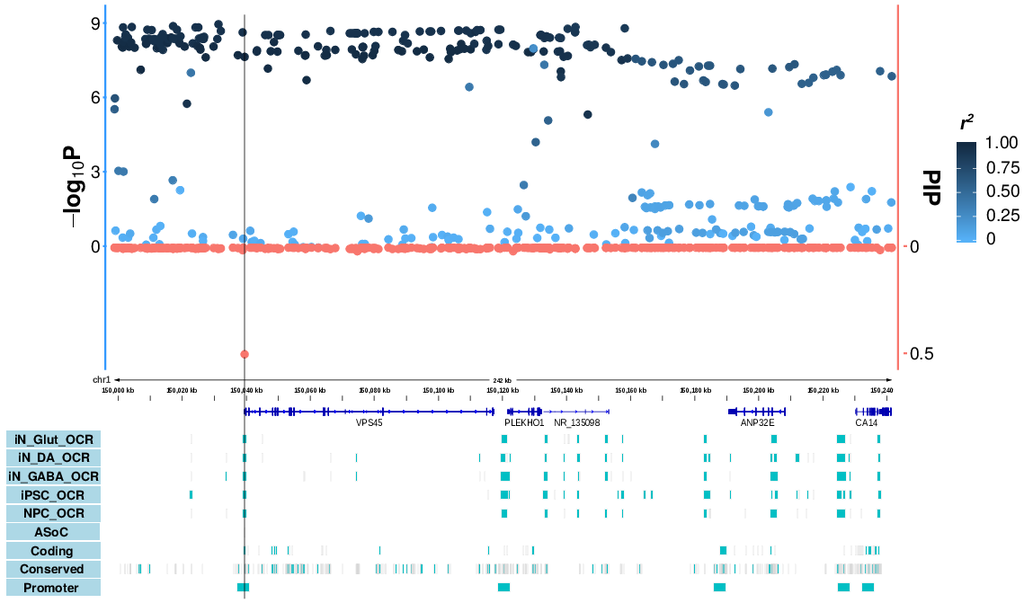

```python
%preview /home/min/Documents/GWAS_ATAC/SCZ_plot/GB_VPS45_20200624.pdf -s png --dpi 50
```

© 2016-2017 Min Qiao at [Xin He lab](http://xinhelab.org), The University of Chicago

Exported from [`workflow/20200518_Manuscripts_Results.ipynb`](http://github.com/gaow/cnv-gene-mapping/blob/345d6d20740960ff008d470162dca36910d6b8ab/workflow/20200518_Manuscripts_Results.ipynb) committed by minqiao on Wed Jul 8 15:22:52 2020 [revision 6, 345d6d2](http://github.com/gaow/cnv-gene-mapping/commit/345d6d20740960ff008d470162dca36910d6b8ab)